# 用資料說故事

2018-05-04

## 大綱

- 資料說故事方法步驟拆解
- 視覺化的規劃
- 視覺化免費工具介紹
- 案例分享：別人如何說故事
- 有趣資料介紹

## 用資料說故事的兩種方法

- 先有問題
- 先有資料

## 先有問題

`「勞動部於五一勞動節前夕舉辦「全國模範勞工表揚典禮」，行政院長賴清德致詞時表示，失業率在 3 月已降到 3.66%，是自 90 年來的新低，勞動參與率高達 58.5%，則是 23 年來新高，勞工平均收入也創歷史新高，來到新台幣 49989 元。「因為有全國勞工的努力，台灣的經濟發展已經走出過去停滯的困境。」` 來源：[NowNews](https://www.nownews.com/news/20180430/2745520)

## 先有問題

`「勞動部於五一勞動節前夕舉辦「全國模範勞工表揚典禮」，行政院長賴清德致詞時表示，失業率在 3 月已降到 3.66%，是自 90 年來的新低，勞動參與率高達 58.5%，則是 23 年來新高，勞工平均收入也創歷史新高，來到新台幣 49989 元。「因為有全國勞工的努力，台灣的經濟發展已經走出過去停滯的困境。」` 來源：[NowNews](https://www.nownews.com/news/20180430/2745520)

- 台灣的經濟發展是否走出停滯困境 -> 難以快速檢驗
- 失業率、勞動參與率、新高新低 -> 可以檢驗

## 先有問題

- 台灣的經濟發展是否走出停滯困境 -> 難以快速檢驗
- 失業率、勞動參與率、新高新低 -> 可以檢驗

[主計總處統計專區：失業率](https://www.stat.gov.tw/point.asp?index=3)

## 先有問題：分析步驟

1. 你的問題是什麼？
2. 心中有可能的答案嗎？答案可能是哪些？一一列舉出來。
3. 怎樣的資料可以回答這個問題？如果我們的答案正確，資料會長怎樣？
4. 找到這些資料。找不到的話，有沒有間接資料？
5. 根據找到的資料，對照 3. 做的設想，檢查資料和哪種答案最為相符。
6. 討論相符／不相符的可能原因。

## 先有問題：分析步驟

1.你的問題是什麼？

我想問：`七年之癢存在嗎？`

-> 把問題的形式轉變成資料可以回答的問題

## 先有問題：分析步驟

1.你的問題是什麼？

我想問：`七年之癢存在嗎？`

-> 把問題的形式轉變成資料可以回答的問題

`人們在結婚第七年的時候，會比其他時候容易離婚嗎？`

## 先有問題：分析步驟

1.你的問題是什麼？

我想問：`七年之癢存在嗎？`

-> 把問題的形式轉變成資料可以回答的問題

`人們在結婚第七年的時候，會比其他時候容易離婚嗎？`

-> 其他時候 = 第一年到第六年、第八年以後

## 先有問題：分析步驟

2.心中有可能的答案嗎？答案可能是哪些？一一列舉出來。

`七年之癢存在嗎？`

`Ans 1. 存在`

`Ans 2. 不存在`

## 先有問題：分析步驟

2.心中有可能的答案嗎？答案可能是哪些？一一列舉出來。

`七年之癢存在嗎？`

`Ans 1. 存在`

-> 人們在結婚第七年的時候，比其他時候容易離婚

`Ans 2. 不存在`

## 先有問題：分析步驟

2.心中有可能的答案嗎？答案可能是哪些？一一列舉出來。

`七年之癢存在嗎？`

`Ans 1. 存在`

-> 人們在結婚第七年的時候，比其他時候容易離婚  
-> 人們在結婚第七年的離婚率比其他年的離婚率高

## 先有問題：分析步驟

2.心中有可能的答案嗎？答案可能是哪些？一一列舉出來。

`七年之癢存在嗎？`

`Ans 1. 存在`

-> 人們在結婚第七年的時候，比其他時候容易離婚  
-> 人們在結婚第七年的離婚率比其他年的離婚率高

`Ans 2. 不存在`

-> 人們在結婚第七年的時候，跟其他時候比起來，並沒有比較容易離婚  
-> 人們在婚後 n 年每年的離婚率差不多，或是離婚率波動，沒有明顯的高低趨勢

## 先有問題：分析步驟

3.怎樣的資料可以回答這個問題？如果我們的答案正確，資料會長怎樣？

假如七年之癢存在  
-> 人們在結婚第七年的離婚率比其他年的離婚率高

## 先有問題：分析步驟

3.怎樣的資料可以回答這個問題？如果我們的答案正確，資料會長怎樣？

假如七年之癢存在  
-> 人們在結婚第七年的離婚率比其他年的離婚率高  
-> 需要人們「結婚年數」對「該年離婚率」的資料

## 先有問題：分析步驟

假如七年之癢存在，資料可能長這樣：

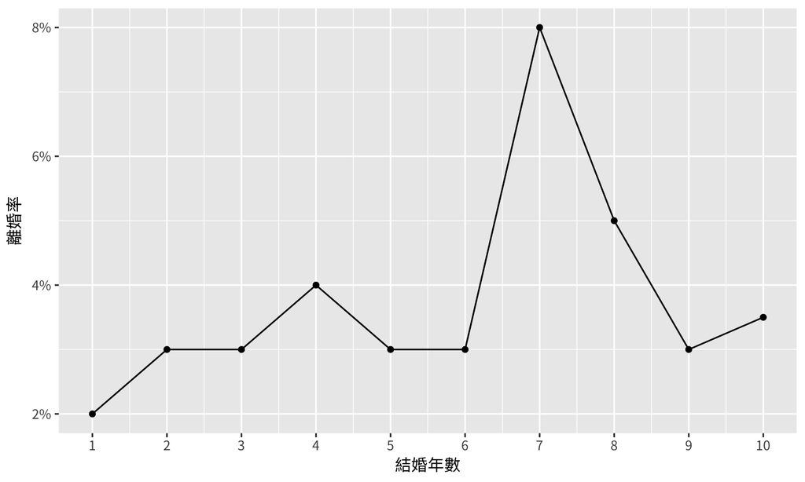

## 先有問題：分析步驟

4.找到這些資料。找不到的話，有沒有間接資料？

## 先有問題：分析步驟

4.找到這些資料。找不到的話，有沒有間接資料？

Google「離婚 台灣」之後找到內政部戶政司的 [網站](https://www.ris.gov.tw/zh_TW/346)

## 先有問題：分析步驟

4.找到這些資料。找不到的話，有沒有間接資料？

Google「離婚 台灣」之後找到內政部戶政司的 [網站](https://www.ris.gov.tw/zh_TW/346)

`最像的是 C.結婚與離婚 / 09離婚對數按結婚期間(按發生)`

## 先有問題：分析步驟

5.根據找到的資料，對照 3. 做的設想，檢查資料和哪種答案最為相符。 `用視覺化來探索！`

我的嘗試： [離婚謎團（上）：七年之癢存在嗎？](https://medium.com/@amossclaire/%E9%9B%A2%E5%A9%9A%E8%AC%8E%E5%9C%98-%E4%B8%8A-%E4%B8%83%E5%B9%B4%E4%B9%8B%E7%99%A2%E5%AD%98%E5%9C%A8%E5%97%8E-41e8e9f480fe)

## 先有資料

- [綜合所得稅申報核定統計專冊](https://ws.fia.gov.tw/001/upload/ias/104%E5%B9%B4%E5%BA%A6%E7%B6%9C%E5%90%88%E6%89%80%E5%BE%97%E7%A8%85%E7%94%B3%E5%A0%B1%E6%A0%B8%E5%AE%9A%E7%B5%B1%E8%A8%88%E5%B0%88%E5%86%8A.html)
- [不動產交易實價登錄](http://lvr.land.moi.gov.tw/homePage.action)

## 先有資料

- [綜合所得稅申報核定統計專冊](https://ws.fia.gov.tw/001/upload/ias/104%E5%B9%B4%E5%BA%A6%E7%B6%9C%E5%90%88%E6%89%80%E5%BE%97%E7%A8%85%E7%94%B3%E5%A0%B1%E6%A0%B8%E5%AE%9A%E7%B5%B1%E8%A8%88%E5%B0%88%E5%86%8A.html)

老梗的統計資料，每年公佈時都會有固定版面。

`「根據財政部『104年度全台所得總額中位數村里統計』，新竹市東區關新里所得中位數達242.5萬元，為全國榜首，全國前14名都由新竹縣市包辦，第15名才是北市內湖的寶湖里。」`來源：[東森財經新聞](https://fnc.ebc.net.tw/FncNews/Content/13777)

`「您知道全台灣最有錢的里在哪嗎？答案就是台北市松山區的精忠里，每戶年收入平均高達989.8萬。」`來源：[ETtoday新聞雲](https://www.ettoday.net/news/20150913/563974.htm)

## 先有資料

- [綜合所得稅申報核定統計專冊](https://ws.fia.gov.tw/001/upload/ias/104%E5%B9%B4%E5%BA%A6%E7%B6%9C%E5%90%88%E6%89%80%E5%BE%97%E7%A8%85%E7%94%B3%E5%A0%B1%E6%A0%B8%E5%AE%9A%E7%B5%B1%E8%A8%88%E5%B0%88%E5%86%8A.html)

有很多主題可以探索：

- 表 16-2A 各級距各類所得金額：不同級距薪資、利息、股利所得的比例
- 表 166-A 各縣市鄉鎮村里各類所得金額：不同地區各類所得比例
- 表 165-A 綜稅所得總額各縣市鄉鎮村里統計：除了哪個里最有錢之外，也可以觀察同一地區逐年變化

## 先有資料

- [不動產交易實價登錄](http://lvr.land.moi.gov.tw/homePage.action)

也是個曝光率很高的老梗的統計資料，有許多相關應用。

- [信義房屋查詢系統](http://tradeinfo.sinyi.com.tw/)
- [信義房屋房價指數](http://www.sinyi.com.tw/knowledge/HPI_season.php/10345/2?_ga=2.166508030.1936027907.1525405905-2142784424.1525405905)

## 先有資料：分析步驟

1. 掃過所有資料，尋找有故事的亮點（新聞點？）
2. 針對亮點，挖資料，找故事
3. 將資料與採訪整合成完整的報導

## 先有資料：分析步驟

1.掃過所有資料，尋找有故事的亮點（新聞點？）

資料： [綜合所得稅申報核定統計專冊](https://ws.fia.gov.tw/001/upload/ias/104%E5%B9%B4%E5%BA%A6%E7%B6%9C%E5%90%88%E6%89%80%E5%BE%97%E7%A8%85%E7%94%B3%E5%A0%B1%E6%A0%B8%E5%AE%9A%E7%B5%B1%E8%A8%88%E5%B0%88%E5%86%8A.html)

`亮點：戰天龍國好像很好玩？`

## 先有資料：分析步驟

2.針對亮點，挖資料，找故事

`問題：天龍國／大安區是所得第一名嗎？` `如果不是（違反常識？），那是哪一區？` `這一區為什麼可以贏天龍國？`

## 先有資料：分析步驟

3.將資料與採訪整合成完整的報導

`問題：天龍國／大安區是所得第一名嗎？` -> 不是耶！！！ `如果不是（違反常識？），那是哪一區？` -> 是內湖寶湖里、文山政大里、新店華城里 `這一區為什麼可以贏天龍國？` -> 都是別墅？有錢人喜歡住山上？

我的嘗試： [雙北所得地圖](https://missmoss.github.io/taipei-income-map/)

## 視覺化如何規劃

要用哪種圖表？

可參考 [金融時報 Visual Vocabulary](https://ft-interactive.github.io/visual-vocabulary-templates/)

## 視覺化如何規劃

`原則：圖表本身可以被獨立閱讀`

## 視覺化如何規劃

`原則：圖表本身可以被獨立閱讀`

- 標題：點出圖表主題
- 座標軸及標題：什麼資料、數值單位
- 圖例：顏色、形狀、大小等，分別代表什麼

## 視覺化如何規劃

圖表的元素們：

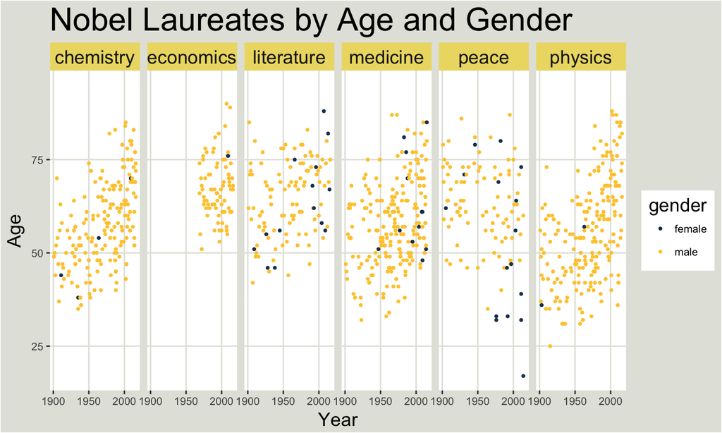

## 視覺化免費工具

- 圖表：plot.ly
- 圖表：plotdb -> 注意每個圖需要的資料長相
- 地圖：carto -> 要有經緯度

## 案例分享：別人如何說故事

- 紐約時報 [全球暖化](https://www.nytimes.com/interactive/2017/01/18/science/earth/2016-hottest-year-on-record.html)
- 紐約時報 [誰是常春藤名校學生](https://www.nytimes.com/interactive/2017/01/18/upshot/some-colleges-have-more-students-from-the-top-1-percent-than-the-bottom-60.html)
- 衛報 [英國脫歐公投結果](https://www.theguardian.com/politics/ng-interactive/2016/jun/23/eu-referendum-live-results-and-analysis)
- 538 [美國的槍殺](https://fivethirtyeight.com/features/gun-deaths/)

## 有趣資料介紹

之前做的有趣資料 [大禮包](https://www.dropbox.com/sh/yth2z6ln336itex/AAD1lHnGeX9g77DaFvcG006ia?dl=0)，內容物包含：

- `guns`：美國槍殺資料（From [Kaggle](https://www.kaggle.com/datasets)）
- `college_admission`：20 年的大學榜單資料
- `traffic`：台北市交通事故資料( [資料欄位說明](http://data.taipei/opendata/datalist/datasetMeta?oid=2f238b4f-1b27-4085-93e9-d684ef0e2735))
- `pokemon`：700 隻寶可夢的基本資料（From [Kaggle](https://www.kaggle.com/datasets)）

中文檔案有 utf8 和 big5 兩種，windows 用戶請下載 big5，macOS/Linus 請下載 utf8

## 有趣資料介紹

之前做的有趣資料 [大禮包](https://www.dropbox.com/sh/yth2z6ln336itex/AAD1lHnGeX9g77DaFvcG006ia?dl=0)，內容物包含：

- `pokemon`：700 隻寶可夢的基本資料（From [Kaggle](https://www.kaggle.com/datasets)）
- `guns`：美國槍殺資料（From [Kaggle](https://www.kaggle.com/datasets)）
- `traffic`：台北市交通事故資料( [資料欄位說明](http://data.taipei/opendata/datalist/datasetMeta?oid=2f238b4f-1b27-4085-93e9-d684ef0e2735))
- `college_admission`：20 年的大學榜單資料

## 有趣資料介紹

`pokemon`：700 隻寶可夢的基本資料（From [Kaggle](https://www.kaggle.com/datasets)）

```
## # A tibble: 6 x 13
##     `#`                  Name `Type 1` `Type 2` Total    HP Attack Defense
##   <int>                 <chr>    <chr>    <chr> <int> <int>  <int>   <int>
## 1     1             Bulbasaur    Grass   Poison   318    45     49      49
## 2     2               Ivysaur    Grass   Poison   405    60     62      63
## 3     3              Venusaur    Grass   Poison   525    80     82      83
## 4     3 VenusaurMega Venusaur    Grass   Poison   625    80    100     123
## 5     4            Charmander     Fire     <NA>   309    39     52      43
## 6     5            Charmeleon     Fire     <NA>   405    58     64      58
## # ... with 5 more variables: `Sp. Atk` <int>, `Sp. Def` <int>,
## #   Speed <int>, Generation <int>, Legendary <chr>
```

## 有趣資料介紹

`guns`：美國槍殺資料（From [Kaggle](https://www.kaggle.com/datasets)）

```
## # A tibble: 6 x 11
##      X1  year month  intent police   sex   age
##   <int> <int> <chr>   <chr>  <int> <chr> <int>
## 1     1  2012    01 Suicide      0     M    34
## 2     2  2012    01 Suicide      0     F    21
## 3     3  2012    01 Suicide      0     M    60
## 4     4  2012    02 Suicide      0     M    64
## 5     5  2012    02 Suicide      0     M    31
## 6     6  2012    02 Suicide      0     M    17
## # ... with 4 more variables: race <chr>, hispanic <int>, place <chr>,
## #   education <int>
```

## 有趣資料介紹

`traffic`：台北市交通事故資料( [資料欄位說明](http://data.taipei/opendata/datalist/datasetMeta?oid=2f238b4f-1b27-4085-93e9-d684ef0e2735))

```
## # A tibble: 6 x 19
##   time.year time.month time.day time.hour time.minute event.level
##       <int>      <int>    <int>     <int>       <int>       <chr>
## 1       104          1        1         0          18        一般
## 2       104          1        1         0          18        一般
## 3       104          1        1         0          18        一般
## 4       104          1        1         0          18        一般
## 5       104          1        1         1          37        一般
## 6       104          1        1         1          37        一般
## # ... with 13 more variables: location.district <chr>,
## #   location.address <chr>, number.dead <int>, number.injury <int>,
## #   party.sn <int>, vehicle.type <chr>, party.gender <chr>,
## #   party.age <int>, party.injury <chr>, location.weather <chr>,
## #   location.speed.limit <int>, location.road.type <chr>,
## #   location.type <chr>
```

## 有趣資料介紹

`college_admission`：20 年的大學榜單資料

```
## # A tibble: 6 x 6
##    year first.name first.pinyin        n national.colleges top.5.colleges
##   <int>      <chr>        <chr>    <dbl>             <dbl>          <dbl>
## 1  1994       艾樺        aihua 1.835502          0.000000       0.000000
## 2  1994       艾琳        ailin 3.671005          1.835502       0.000000
## 3  1994       艾倫        ailun 1.835502          1.835502       1.835502
## 4  1994       艾寧       aining 1.835502          0.000000       0.000000
## 5  1994       艾如         airu 1.835502          0.000000       0.000000
## 6  1994       艾雯        aiwen 3.671005          1.835502       0.000000
```

## 資料去哪挖

- [政府資料開放平台](https://data.gov.tw/)
- [中華民國統計資訊網](https://www.stat.gov.tw/np.asp?ctNode=452)
- [Kaggle](https://www.kaggle.com/datasets)
- Google 關鍵字